# | Mate Allocation of Breeding Crosses

Optimal Cross Selection — Theory and Simulations

Marco Antonio Peixoto, Associate researcher[^1]

Gainesville, 2026

# Introduction

Mate selection is the process of choosing mating pairs or groups — that is, the simultaneous selection and mate allocation of individuals entering a breeding program. An extension of optimum contribution selection that delivers a practical crossing plan is to jointly optimize contributions and cross allocations (Kinghorn et al., 2009; Woolliams, 2015; Gorjanc et al., 2018).

In optimal cross selection, we combine two pieces of information for each candidate cross:

- **Criterion**: a measure of cross performance (e.g., mid-parental value, total genetic value, or usefulness criterion).
- **relatedness**: a measure between the parents, used to manage inbreeding and maintain diversity.

The goal is to find a crossing plan that maximizes genetic gain while constraining the rate of inbreeding to an acceptable level.

# Managing Genetic Diversity

Genetic variation is crucial for long-term genetic progress. Unconstrained selection maximizes short-term gain but erodes diversity and increases inbreeding, reducing future response.

Inbreeding ($F$) can be estimated via:

- Relative decrease in heterozygosity or expected heterozygosity.
- Runs of homozygosity (ROH).
- Genomic relationship matrices (A: tracking IBD and G: tracking IBS).

In a breeding scenario, $F$ and $\Delta F$ relates as follows:

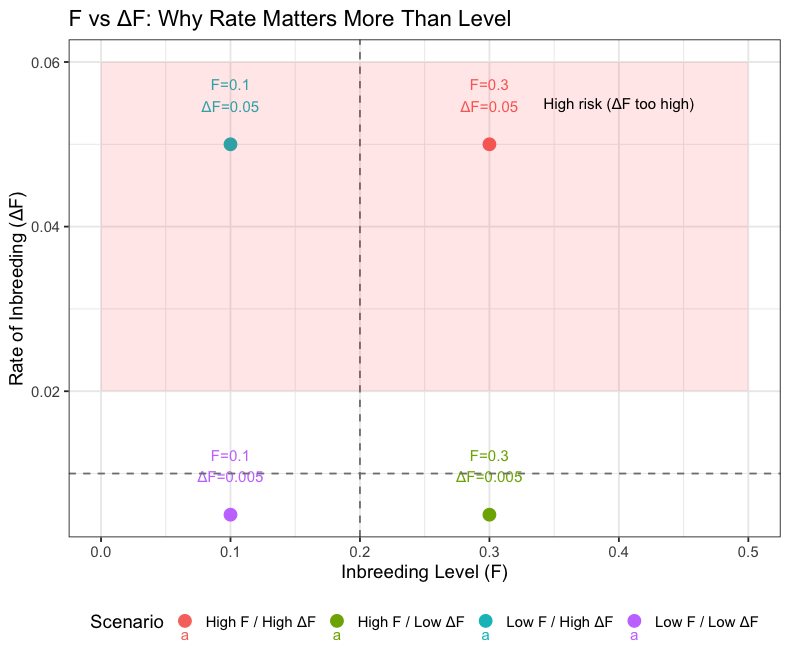

> **Key consideration:** If $\Delta F$ is controlled and kept constant, the **future trajectory of inbreeding is similar regardless of the current level of $F$**. This is why breeders target $\Delta F$ as the management variable, not $F$ itself.

Below, we will implement two algorithms to optimize crossing plan based on a criterion (total genetic value) and inbreeding (coming from a realized relationship matrix). The implementations are from **SimpleMating** and **COMA** packages. A base population of individuals will be created and individuals derived from that using **AlphaSimR** package.

# Optimization of crosses

In this first exercise, we set up a simulated breeding population using AlphaSimR, compute the total genetic values for all possible crosses, and select an optimized mating plan.

## Setting up the population

```r
rm(list = ls())

# Loading packages
# install.packages("COMA") # if needed istall it
library(COMA)
library(AlphaSimR)
library(AGHmatrix)
library(SimpleMating)

set.seed(52684)

# Creating the founding genome
founderGenomes <- runMacs(nInd = 200,
                          nChr = 10,
                          segSites = 500)

# Global simulation parameters from founder genomes
SP <- SimParam$new(founderGenomes)

# Additive + dominance trait
SP$addTraitAD(nQtlPerChr = 200,
              mean = 10,
              var = 10,
              meanDD = 0.9,
              varDD = 0.3)

SP$addSnpChip(300)
SP$setVarE(varE = 20)

# Generating base population in HWE
Parents <- newPop(founderGenomes)
```

## Creating population structure

We advance the population through 100 generations of selection to create linkage disequilibrium and population structure, mimicking a real breeding population.

```r
ParentsPop <- Parents

for (year in 1:100) {
  set.seed(6985)
  ParentsPop <- setPheno(ParentsPop, h2 = 0.4)
  ParentsPop <- selectCross(pop = ParentsPop, nInd = 10, nCrosses = 150)
}
```

## Checking inbreeding levels

We can compare inbreeding levels across different population states using the genomic relationship matrix. Note that the G matrix (IBS) from the doubled-haploid population indicates and F = 1.

```r
# HWE (founder population)
relMat_HWE <- AGHmatrix::Gmatrix(pullSnpGeno(Parents))
```

[output not shown]

```r
# After 100 generations of selection (no longer in HWE)
relMat_noHWE <- AGHmatrix::Gmatrix(pullSnpGeno(ParentsPop))
```

[output not shown]

```r
# Doubled haploids from the selected population
ParentsPop_DH <- makeDH(ParentsPop, nDH = 2)
relMat_DH <- AGHmatrix::Gmatrix(pullSnpGeno(ParentsPop_DH))
```

[output not shown]

## Computing Total Genetic Values

Using SimpleMating, we compute the total genetic value (TGV) for all possible half-diallel crosses.

```r
# 1. Creating the mating plan (all pairwise crosses)
CrossPlan <- planCross(TargetPop = ParentsPop@id,
                       MateDesign = "half")
```

```
## Number of potential crosses generated: 11175
```

```r
# 2. Relationship matrix
relMat <- AGHmatrix::Gmatrix(pullQtlGeno(ParentsPop))
```

[output not shown]

```r
# 3. QTL genotypes
Markers <- pullQtlGeno(ParentsPop)

# 4. Marker effects
add_eff <- SP$traits[[1]]@addEff
dom_eff <- SP$traits[[1]]@domEff

# 5. Compute TGV for all crosses
ST_tgv <- getTGV(MatePlan = CrossPlan,
                 Markers = Markers,
                 addEff = add_eff,
                 domEff = dom_eff,
                 ploidy = 2,
                 K = relMat)
```

```
## TGVs predicted for 11175 crosses.
```

```r
head(ST_tgv, 20)
```

```
##    Parent1 Parent2        Y           K
## 1    15051   15052 48.49128  0.27732908
## 2    15051   15053 48.76521  0.28877597
## 3    15051   15054 51.50141 -0.43192639
## 4    15051   15055 49.67416 -0.17181082
## 5    15051   15056 49.03153  0.02022586
## 6    15051   15057 47.73578  0.08679857
## 7    15051   15058 49.88101  0.08634672
## 8    15051   15059 49.18132 -0.14680840
## 9    15051   15060 48.70614  0.33230428
## 10   15051   15061 50.68784 -0.28296617
## 11   15051   15062 48.90147  0.02489498
## 12   15051   15063 48.50213  0.11511457
## 13   15051   15064 47.58813  0.23319830
## 14   15051   15065 49.23301  0.15517869
## 15   15051   15066 48.93509  0.10713187
## 16   15051   15067 50.12453 -0.20268731
## 17   15051   15068 48.83394  0.02203326
## 18   15051   15069 49.18187  0.01887030
## 19   15051   15070 49.17813  0.04824062
## 20   15051   15071 49.44040  0.12294665
```

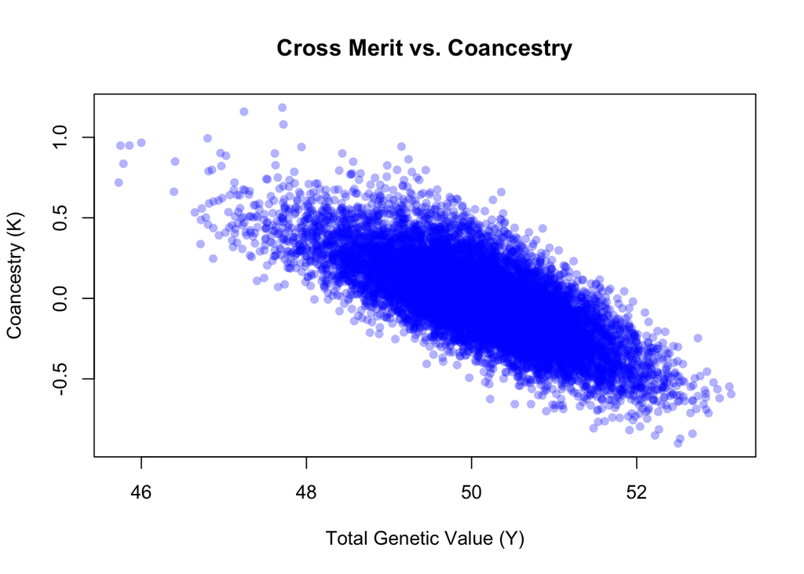

```r
plot(ST_tgv$Y, ST_tgv$K,
     xlab = "Total Genetic Value (Y)",
     ylab = "Coancestry (K)",
     main = "Cross Merit vs. Coancestry",
     pch = 16, col = rgb(0, 0, 1, 0.3))
```

## Optimization with SimpleMating

The `selectCrosses()` function in SimpleMating uses an algorithm to select an optimal subset of crosses that maximizes the criterion while constraining relatedness (culling.pairwise.k).

```r
MatingPlan <- selectCrosses(data = ST_tgv,
                            n.cross = 100,
                            max.cross = 4,
                            culling.pairwise.k = 0)

# Summary statistics
MatingPlan[[1]]
```

```
##   culling.pairwise.k target.Y   target.K
## 1                  0 52.03096 -0.5200644
```

```r
# Selected mating plan
head(MatingPlan[[2]], 6)
```

```
##   Parent1 Parent2        Y          K
## 1   15167   15193 52.86967 -0.7126765
## 2   15089   15137 52.85122 -0.4552720
## 3   15167   15200 52.84035 -0.6905358
## 4   15165   15196 52.83736 -0.5909779
## 5   15111   15140 52.82395 -0.5700422
## 6   15059   15137 52.81030 -0.6584544
```

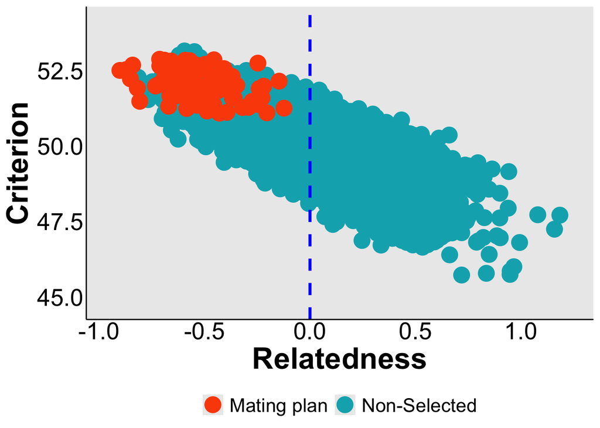

```r
# Optimization plot
MatingPlan[[3]]
```

## Optimization with COMA

COMA (Convex Optimization for Mate Allocation) uses a Lagrangian approach to optimize mate allocation. It directly constrains the rate of inbreeding ($\Delta F$) and finds optimal contribution proportions for each cross.

```r
# 1. Coancestry matrix (halved relationship matrix)
KCoan <- relMat / 2

# 2. Compute TGV with coancestry matrix
OMAtgv <- getTGV(MatePlan = CrossPlan,
                 Markers = Markers,
                 addEff = add_eff,
                 domEff = dom_eff,
                 ploidy = 2,
                 K = KCoan)
```

```
## TGVs predicted for 11175 crosses.
```

```r
OMAtgv$Parent1 <- as.character(OMAtgv$Parent1)
OMAtgv$Parent2 <- as.character(OMAtgv$Parent2)

# 3. Parent constraints
parentsID <- data.frame(id = ParentsPop@id,
                        min = 0,
                        max = 1)

# 4. Mating constraints
matingsID <- data.frame(parent1 = OMAtgv$Parent1,
                        parent2 = OMAtgv$Parent2,
                        merit = OMAtgv$Y,
                        min = 0,
                        max = 1)

# 5. Optimization (5% inbreeding increment constraint)
omaModel <- COMA::oma(dF = 0.025, # 0.25%
                      parents = parentsID,
                      matings = matingsID,
                      ploidy = 2,
                      K = KCoan,
                      dF.adapt = list(step = 0.001, max = 0.2),
                      base = "current")

# 6. Derive 100 crosses from optimal contributions
rep_times <- round(omaModel$om$value * 100)

MatingPlan_COMA <- data.frame(
  Parent1 = rep(omaModel$om$parent1, times = rep_times),
  Parent2 = rep(omaModel$om$parent2, times = rep_times))

head(MatingPlan_COMA, 6)
```

```
##   Parent1 Parent2
## 1   15053   15169
## 2   15054   15185
## 3   15061   15140
## 4   15061   15140
## 5   15061   15140
## 6   15061   15140
```

# Breeding Program Simulation: GS vs. OCS

This section compares two breeding strategies over 10 years:

1. **Genomic Selection (GS)**: Standard pipeline with random mating of selected parents.
2. **Optimal Cross Selection (OCS)**: Same pipeline but with optimized mate allocation using SimpleMating.

## Helper functions

```r
# Inbreeding based on expected heterozygosity
inbCoef = function(Pop){

  Markers = pullQtlGeno(Pop)
  p = colMeans(Markers)/Pop@ploidy
  f = sum(p^2)/ncol(Markers)

  return(f)
}

# inbreeding based on IBS
calcFibs = function(Markers, refPop, ploidy = NULL){

  W_allele <- pullQtlGeno(refPop)
  W = Markers

  ##### Allele frequency coming from the reference population
  af = apply(W_allele, 2, function(x) mean(x, na.rm = T)/ploidy) # Allele frequency

  freq_p = ifelse(af < 0.5, af, 1-af) # Minor allele frequency
  P_allele <- matrix(rep(af,nrow(W)),ncol=ncol(W),byrow=T) # Freq P matrix

  twopq <- ploidy*(t(freq_p)%*%(1-freq_p)) # two*p*q

  Z = W - ploidy*P_allele
  Z[is.na(Z)] <- 0

  gMatrix <- (tcrossprod(Z,Z))/as.numeric(twopq) # G matrix

  return((mean(diag(gMatrix))-1)/(refPop@ploidy - 1))


}


# Estimation of inbreeding rating through generation
fdF <- function(x) {
  x <- pmin(x, 1)
  nx <- length(x)
  1 - ((1-x)/(1-x[1]))^(1/(1:nx))
}
```

## Simulation setup

```r
rm(list = ls()[!ls() %in% c("inbCoef", "calcFibs", "fdF")])

# Loading packages
library(AlphaSimR)
library(AGHmatrix)
library(SimpleMating)
library(ggplot2)
library(ggpubr)


set.seed(52684)
# Creating the founding genome
founderGenomes = runMacs(nInd = 200, # Number of individuals that compose the genome
                         nChr = 10,   # Number of chromosome pairs of the target species
                         segSites = 10000)  # number of segregation sites
# Global simulation parameters from founder genomes.
SP = SimParam$new(founderGenomes)

# Additive trait
SP$addTraitA(nQtlPerChr = 1000, # Number of QTL per chromosome
             mean = 100, # Trait additive mean
             var = 100) # Trait additive variance or varA
SP$addSnpChip(500)

SP$setVarE(h2=0.5)

# Generating base population
Parents = newPop(founderGenomes)
ParentsPop = Parents
refPop = Parents
```

## Burn-in phase (10 years)

The burn-in establishes a realistic breeding population with a training set for genomic prediction.

```r
for(year in 1:10){
  cat("Working on year:", year, "\n")

#------------- Year 1
set.seed(6985)
Clones = randCross(pop = ParentsPop, nCrosses = 100) # Crossing block

#------------- Year 2
cloneStage = setPheno(pop = Clones, h2 = 0.1, reps = 1) # h2 = 0.1 (visual selection)
PrelimTrial = selectInd(cloneStage, nInd = 60, use = "pheno")

#-------------  Year 3
PrelimTrial = setPheno(PrelimTrial, varE = 20, reps = 1) # h2 = 10/(10+20/1) = 0.33
AdvancTrial = selectInd(PrelimTrial, nInd = 50, use = "pheno") # Preliminary Trial

#------------- Year 4
AdvancTrial = setPheno(AdvancTrial, varE = 20, reps = 5) # h2 = 10/(10+20/5) = 0.71
EliteTrial = selectInd(AdvancTrial, nInd = 5, use = "pheno") # Advanced Trial

#------------- Year 5
EliteTrial = setPheno(EliteTrial, varE = 20, reps = 20) # h2 = 10/(10+20/20) = 0.90
Variety = selectInd(EliteTrial, nInd = 2, use = "pheno") # Elite Trial

# Updating the parents
Parents = mergePops(list(EliteTrial,Parents))
ParentsPop = selectInd(Parents, nInd = 5, use = "pheno")

# calibrate the model
AdvancTrial@fixEff = as.integer(rep(paste0(year),nInd(AdvancTrial)))
EliteTrial@fixEff = as.integer(rep(paste0(year),nInd(EliteTrial)))
PrelimTrial@fixEff = as.integer(rep(paste0(year),nInd(PrelimTrial)))

if(year >= 5){

  if(!exists("trainPop") || is.null(trainPop)){
    trainPop <-c(AdvancTrial, EliteTrial, PrelimTrial)
  } else {
    trainPop <- mergePops(list(trainPop, c(AdvancTrial, EliteTrial, PrelimTrial)))
  }

}

}

## -----
burnInPop = Parents
trainPop_burnin = trainPop
```

## Allocate tracking vectors

```r
nYears <- 10 + 1
meanG_Scen1 <- meanG_Scen2 <- numeric(nYears)
fInb_Scen1 <- fInb_Scen2 <- numeric(nYears)
fIbs_Scen1 <- fIbs_Scen2 <- numeric(nYears)
genicA_Scen1 <- genicA_Scen2 <- numeric(nYears)

# Starting values
meanG_Scen1[1] <- meanG_Scen2[1] <- meanG(burnInPop)
genicA_Scen1[1] <- genicA_Scen2[1] <- genicVarA(burnInPop)
fIbs_Scen1[1] <- fIbs_Scen2[1] <- calcFibs(
  Markers = pullQtlGeno(burnInPop), refPop = refPop, ploidy = 2)
fInb_Scen1[1] <- fInb_Scen2[1] <- inbCoef(burnInPop)
```

## Scenario 1 — Baseline Genomic Selection

Standard genomic selection pipeline: parents are selected on GEBVs and crossed randomly.

```r
# From the same population
Parents = burnInPop
trainPop  = trainPop_burnin

# Loop
for (year in 2:nYears){
  cat("Working on year:", year, "\n")

  gsmodel = RRBLUP(trainPop , use = 'pheno', useReps = TRUE) # Calibrate the genomic model
  if(year == 2){ Parents = setEBV(Parents, gsmodel)}

  set.seed(11)

  #------------- Year 1
  Clones = randCross(pop = Parents, nCrosses = 100) # Crossing block
  Clones = setEBV(Clones, gsmodel)
  PrelimTrial = selectInd(Clones, nInd = 60, use = "ebv")

  # #------------- Year 2
  # cloneStage = setPheno(pop = Clones, h2 = 0.1, reps = 1) # h2 = 0.1 (visual selection)
  # PrelimTrial = selectInd(cloneStage, nInd = 60, use = "pheno")

  #-------------  Year 3
  PrelimTrial = setPheno(PrelimTrial, varE = 20, reps = 1)
  AdvancTrial = selectInd(PrelimTrial, nInd = 10, use = "pheno") # Preliminary Trial

  #------------- Year 4
  AdvancTrial = setPheno(AdvancTrial, varE = 20, reps = 5)
  EliteTrial = selectInd(AdvancTrial, nInd = 5, use = "pheno") # Advanced Trial

  #------------- Year 5
  EliteTrial = setPheno(EliteTrial, varE = 20, reps = 20)
  Variety = selectInd(EliteTrial, nInd = 2, use = "pheno") # Elite Trial

  #------------- Year 6
  # Release varieties

  # Updating the parents
  Parents = selectInd(Clones, nInd = 60, use = "ebv")

  AdvancTrial@fixEff = as.integer(rep(paste0(year, 1L),nInd(AdvancTrial)))
  EliteTrial@fixEff = as.integer(rep(paste0(year, 1L),nInd(EliteTrial)))
  PrelimTrial@fixEff = as.integer(rep(paste0(year, 1L),nInd(PrelimTrial)))

  # Track performance
  meanG_Scen1[year] = meanG(Parents)
  genicA_Scen1[year] = genicVarA(Parents)
  fInb_Scen1[year] = inbCoef(Parents)
  fIbs_Scen1[year] = calcFibs(Markers = pullQtlGeno(Parents), refPop = refPop, ploidy = 2)

  # calibrate model
  if(year !=2){
    trainPop  = trainPop[-c(1:nInd(c(AdvancTrial, EliteTrial, PrelimTrial)))]
    trainPop  = mergePops(list(trainPop, c(AdvancTrial, EliteTrial, PrelimTrial)))
  }else{
    trainPop  = mergePops(list(trainPop, c(AdvancTrial, EliteTrial, PrelimTrial)))
  }

}
```

## Scenario 2 — Optimal Cross Selection

```r
# From the base population
Parents = burnInPop
trainPop  = trainPop_burnin

# Loop
for (year in 2:nYears){

  cat("Working on year:", year, "\n")
  gsmodel = RRBLUP(trainPop , use = 'pheno', useReps = TRUE)
  Parents = setEBV(Parents, gsmodel)

  set.seed(11)
  #------------- Year 1

  # 1. Criterion
  crit <- data.frame(Id = Parents@id,
                     Criterion = Parents@ebv)

  # 2. Creating relationship matrix
  relMat <- Gmatrix(pullSnpGeno(Parents))

  # 3.Mating Plan
  CrossPlan <- planCross(TargetPop = Parents@id)

  # 4.Single trait mid-parental value
  mpv <- getMPV(MatePlan = CrossPlan,
                     Criterion = crit,
                     K = relMat)

  # 5. Optimize
  matingPlan <- selectCrosses(mpv,
                              n.cross = 100,
                              max.cross = 4,
                              min.cross = 1,
                              culling.pairwise.k = 0)

  plan = as.matrix(matingPlan[[2]][, c(1,2)])

  # Cross
  Clones = makeCross(Parents, plan)

  # GS them
  Clones = setEBV(Clones, gsmodel)
  PrelimTrial = selectInd(Clones, nInd = 60, use = "ebv")

  #-------------  Year 3
  PrelimTrial = setPheno(PrelimTrial, varE = 20, reps = 1)
  AdvancTrial = selectInd(PrelimTrial, nInd = 50, use = "pheno") # Preliminary Trial

  #------------- Year 4
  AdvancTrial = setPheno(AdvancTrial, varE = 20, reps = 5)
  EliteTrial = selectInd(AdvancTrial, nInd = 20, use = "pheno") # Advanced Trial

  #------------- Year 5
  EliteTrial = setPheno(EliteTrial, varE = 20, reps = 20)
  Variety = selectInd(EliteTrial, nInd = 2, use = "pheno") # Elite Trial

  #------------- Year 6
  # Release varieties

  # Track performance
  meanG_Scen2[year] = meanG(Parents)
  genicA_Scen2[year] = genicVarA(Parents)
  fInb_Scen2[year] = inbCoef(Parents)
  fIbs_Scen2[year] = calcFibs(Markers = pullQtlGeno(Parents), refPop = refPop, ploidy = 2)

  # Updating the parents
  Parents = Clones

  # calibrate model
  AdvancTrial@fixEff = as.integer(rep(paste0(year, 1L),nInd(AdvancTrial)))
  EliteTrial@fixEff = as.integer(rep(paste0(year, 1L),nInd(EliteTrial)))
  PrelimTrial@fixEff = as.integer(rep(paste0(year, 1L),nInd(PrelimTrial)))

  # calibrate model
  if(year !=2){
    trainPop  = trainPop[-c(1:nInd(c(AdvancTrial, EliteTrial, PrelimTrial)))]
    trainPop  = mergePops(list(trainPop, c(AdvancTrial, EliteTrial, PrelimTrial)))
  }else{
    trainPop  = mergePops(list(trainPop, c(AdvancTrial, EliteTrial, PrelimTrial)))
  }
}
```

# Results — Comparing GS vs. OCS

## Preparing data for visualization

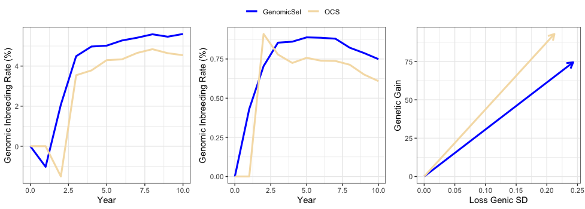

```r
###---- Scenario one
dfScen1 <- data.frame(scenario = "GenomicSel",
                  meanG = meanG_Scen1,
                  Fgmat = fIbs_Scen1,
                  Ffreq = fInb_Scen1,
                  GenicVarG = genicA_Scen1)
dfScen1$Year <- 0:10
dfScen1$dFgmat <- 100*fdF(dfScen1$Fgmat)
dfScen1$dFfreq <- 100*fdF(dfScen1$Ffreq)
dfScen1$diversity <- 1-sqrt(dfScen1$GenicVarG)/sqrt(dfScen1$GenicVarG[1])
dfScen1$gain <- dfScen1$meanG - dfScen1$meanG[1]

###---- Scenario two
dfScen2 <- data.frame(scenario = "OCS",
                      meanG = meanG_Scen2,
                      Fgmat = fIbs_Scen2,
                      Ffreq = fInb_Scen2,
                      GenicVarG = genicA_Scen2)
dfScen2$Year <- 0:10
dfScen2$dFgmat <- 100*fdF(dfScen2$Fgmat)
dfScen2$dFfreq <- 100*fdF(dfScen2$Ffreq)
dfScen2$diversity <- 1-sqrt(dfScen2$GenicVarG)/sqrt(dfScen2$GenicVarG[1])
dfScen2$gain <- dfScen2$meanG - dfScen2$meanG[1]

pdat <- rbind(dfScen1,dfScen2)

###---- Plot one
p1 <- ggplot(pdat, mapping=aes(x=Year, y=dFgmat, col=scenario)) +
  ylab("Genomic Inbreeding Rate (%)") +
  theme_bw() +
  geom_line(data=pdat, linewidth=1.1) +
  scale_color_manual(values = c("blue", "wheat"), name = NULL)

p2 <- ggplot(pdat, mapping=aes(x=Year, y=dFfreq, col=scenario)) +
  ylab("Genomic Inbreeding Rate (%)") +
  theme_bw() +
  geom_line(data=pdat, linewidth=1.1) +
  scale_color_manual(values = c("blue", "wheat"), name = NULL)


# Plot three
df_p3 <- merge(aggregate(gain~scenario+Year,data=pdat,FUN=mean),
              aggregate(diversity~scenario+Year,data=pdat,FUN=mean))
df_p3 <- df_p3[df_p3$Year==10,]; df_p3$x <- 0; df_p3$y <- 0


p3 <- ggplot() +
  theme_bw() +
  geom_line(data=df_p3,
            mapping=aes(x=diversity, y=gain,
                        col=scenario),
            alpha=0.05) +
  ylab("Genetic Gain") +
  xlab("Loss Genic SD") +
  geom_segment(data=df_p3,
               arrow = arrow(length = unit(0.3, "cm")),
               mapping=aes(x=x, y=y,
                           xend=diversity, yend=gain,
                           col=scenario),
               linewidth=1.1) +
  scale_color_manual(values =  c("blue", "wheat"), name = NULL)


ggarrange(p1,p2,p3,nrow=1,common.legend = TRUE)
```

# References

- Akdemir, D., Sanchez, J. I., & Jannink, J.-L. (2016). Optimization of genomic selection training populations with a genetic algorithm. G3: Genes, Genomes, Genetics, 6(3), 721–731.
- Allier, A., Teyssèdre, S., Lehermeier, C., Moreau, L., & Charcosset, A. (2019). Optimized breeding strategies to harness genetic resources with different performance levels. G3: Genes, Genomes, Genetics, 9(5), 1593–1605.
- Falconer, D. S., & Mackay, T. F. C. (1996). Introduction to Quantitative Genetics (4th ed.). Longman, Harlow, UK.
- Fernández-González, J., Metwally, S. M., & Isidro y Sánchez, J. (2026). MateR: a novel genomic mating framework. Genetics, iyag013.
- Gorjanc, G., Gaynor, R. C., & Hickey, J. M. (2018). Optimal cross selection for long-term genetic gain in two-part programs with rapid recurrent genomic selection. Genetics, 210(4), 1241–1259.
- Kinghorn, B. P. (1999). An algorithm for efficient constrained mate selection. Livestock Production Science, 59(2–3), 119–130.
- Kinghorn, B. P., et al. (2009). Mate selection in livestock breeding programs: Advances and challenges. In: Proceedings of the Association for the Advancement of Animal Breeding and Genetics (AABG).
- Lehermeier, C., Teyssèdre, S., & Schön, C.-C. (2017). Genomic prediction of within-family variance in biparental populations. Genetics, 207(4), 1631–1644.
- Peixoto, M. A., Amadeu, R. R., Bhering, L. L., Ferrão, L. F. V., Munoz, P. R., & Resende Jr, M. F. (2025). SimpleMating: R‐package for prediction and optimization of breeding crosses using genomic selection. The plant genome, 18(1), e20533.
- Wolfe, M. D., et al. (2021). Genomic mating in outbred species: predicting cross usefulness in cassava breeding. The Plant Genome, 14(1), e20099.
- Woolliams, J. A. (2015). Optimal contribution selection and the management of genetic diversity. In: Proceedings of the 66th Annual Meeting of the European Federation of Animal Science (EAAP).
[^1]: University of Florida, deamorimpeixotom@ufl.edu